# Skrypty geoprzetwarzania

Klasyfikacja danych

Author

Krzysztof Dyba

```r
library("terra")
```

# Pozyskanie danych

W repozytorium [Zenodo](https://zenodo.org/records/7299645) znajdziesz archiwum *.zip* zawierające zobrazowania satelitarne z Landsata, mapę pokrycia terenu [Sentinel-2 Global Land Cover](https://s2glc.cbk.waw.pl/) z legendą zapisaną w pliku *.csv* oraz poligon z zasięgiem powiatu śremskiego w formacie *.gpkg*. Struktura katalogu wygląda następująco:

```
dane/
.. dane/
.... powiat_sremski.gpkg
.... S2GLC_T33UXT.csv
.... S2GLC_T33UXT.tif
.... landat/
...... LC08_L2SP_190024_20200418_20200822_02_T1_MTL.xml
...... LC08_L2SP_190024_20200418_20200822_02_T1_SR_B1.TIF
...... LC08_L2SP_190024_20200418_20200822_02_T1_SR_B2.TIF
...... LC08_L2SP_190024_20200418_20200822_02_T1_SR_B3.TIF
...... LC08_L2SP_190024_20200418_20200822_02_T1_SR_B4.TIF
...... LC08_L2SP_190024_20200418_20200822_02_T1_SR_B5.TIF
...... LC08_L2SP_190024_20200418_20200822_02_T1_SR_B6.TIF
...... LC08_L2SP_190024_20200418_20200822_02_T1_SR_B7.TIF
```

Dostęp do zaprezentowanych plików możemy uzyskać bez potrzeby ich całkowitego pobierania używając modułów `/vsizip/` (dostęp do archiwów *.zip*) oraz `/vsicurl/` (zdalny dostęp do plików). Kolejność operacji jest następująca – najpierw musimy połączyć się ze źródłem, a później uzyskać dostęp do archiwum, czyli w naszym przypadku będzie to:

```
1. /vsicurl/https://zenodo.org/records/7299645/files/dane.zip
2. /vsizip/vsicurl/https://zenodo.org/records/7299645/files/dane.zip
```

Następnie używając ukośników (`/`) należy odwołać się do określonego pliku:

```
3. /vsizip/vsicurl/https://zenodo.org/records/7299645/files/dane.zip/dane/dane/S2GLC_T33UXT.tif
```

Wczytajmy teraz wszystkie niezbędne dane.

```r
url = "https://zenodo.org/records/7299645/files/dane.zip"
```

```r
s2glc = paste0("/vsizip/vsicurl/", url, "/dane/dane/S2GLC_T33UXT.tif")
s2glc = rast(s2glc)
```

```r
poly = paste0("/vsizip/vsicurl/", url, "/dane/dane/powiat_sremski.gpkg")
poly = vect(poly)
```

```r
landsat = c("LC08_L2SP_190024_20200418_20200822_02_T1_SR_B1.TIF",
            "LC08_L2SP_190024_20200418_20200822_02_T1_SR_B2.TIF",
            "LC08_L2SP_190024_20200418_20200822_02_T1_SR_B3.TIF",
            "LC08_L2SP_190024_20200418_20200822_02_T1_SR_B4.TIF",
            "LC08_L2SP_190024_20200418_20200822_02_T1_SR_B5.TIF",
            "LC08_L2SP_190024_20200418_20200822_02_T1_SR_B6.TIF",
            "LC08_L2SP_190024_20200418_20200822_02_T1_SR_B7.TIF")
landsat = paste0("/vsizip/vsicurl/", url, "/dane/dane/landsat/", landsat)
landsat = rast(landsat)
names(landsat) = paste0("B", 1:7) # zamień nazwy
```

```r
legenda = paste0("/vsizip/vsicurl/", url, "/dane/dane/S2GLC_T33UXT.csv")
legenda = vect(legenda)
```

W przypadku legendy musimy zastosować dwa dodatkowe kroki polegające na zamianie obiektu wektorowego (SpatVector) na prostą ramkę danych (ponieważ ten obiekt de facto nie posiada geometrii) oraz zamianie typu atrybutu ID z tekstowego na liczbę całkowitą.

```r
legenda = as.data.frame(legenda)
legenda$ID = as.integer(legenda$ID)
```

# Przygotowanie danych

Pozyskane rastry różnią się rozdzielczością przestrzenną (scena Landsat ma 30 m, natomiast klasy pokrycia terenu 10 m). Kiedy rastry posiadają różne rozdzielczości, to nie jest możliwe wykonywanie na nich operacji matematycznych. W takim przypadku musimy sprowadzić je do jednakowej rozdzielczości. Ten proces nazywa się przepróbkowaniem (*resampling*).

Przepróbkowanie można wykonać:

- Z większej rozdzielczości do mniejszej, np. 100 m -> 500 m (*downsampling*, *downscaling*)
- Z mniejszej rozdzielczości do większej, np. 500 m -> 100 m (*upsampling*, *upscaling*)

Z racji iż proste metody przepróbkowania nie zwiększają ilości informacji przy zwiększaniu rozdzielczości przestrzennej, to lepiej wykonać przepróbkowanie do niższej rozdzielczości.

Przepróbkowanie można wykonać przy pomocy funkcji `resample()`. Dostępne są różne metody przepróbkowania, ale w przypadku danych kategorycznych, koniecznie trzeba wykorzystać algorytm najbliższego sąsiada (`method = "near"`) lub wartość modalną, dominantę (`method = "mode"`). Jeśli tego nie zrobimy, to ID kategorii zostaną zmienione.

```r
s2glc = resample(s2glc, landsat, method = "near")
res(s2glc)
```

```
[1] 30 30
```

Dotnijmy nasze warstwy do zasięgu poligonu.

```r
landsat = crop(landsat, poly, mask = TRUE)
s2glc = crop(s2glc, poly, mask = TRUE)
```

Zauważ, że wartości odbicia spektralnego nie są w zakresie od 0 do 1. Oznacza to, że samodzielnie musimy dokonać korekcji. W przypadku danych z Landsata 8, parametry są następujące:

- współczynnik skalowania: $0.0000275$
- przesunięcie: $-0.2$

```r
landsat = landsat * 0.0000275 - 0.2
```

Usuńmy jeszcze wartości odstające używając funkcji `clamp()`.

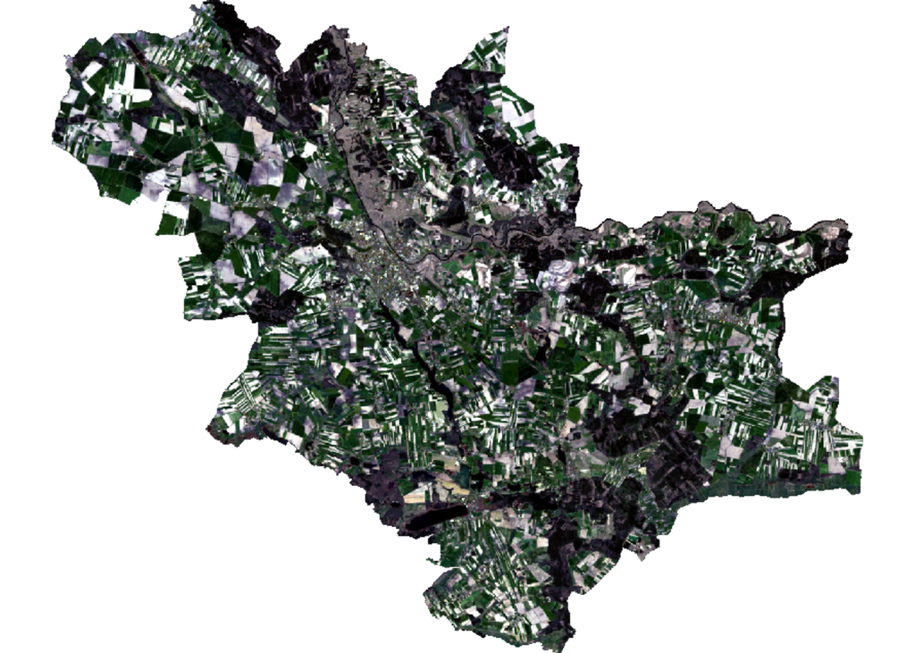

```r
landsat = clamp(landsat, lower = 0, upper = 1, values = FALSE)
plotRGB(landsat, r = 4, g = 3, b = 2, stretch = "lin")
```

Tak jak podczas klasteryzacji, algorytmy klasyfikacji nadzorowanej również wymagają określonej struktury danych wejściowych, np. ramki danych (*data frame*). Jednak znaczącą różnicą jest obecność zmiennej referencyjnej (w naszym przykładzie klasy pokrycia terenu). Pozostałe kolumny to zmienne wyjaśniające.

```r
dane = cbind(values(s2glc), values(landsat)) # połączenie kolumn w macierzy
dane = as.data.frame(dane) # konwersja macierzy do ramki danych
dane = na.omit(dane) # usunięcie brakujących wartości
```

Jedna z klas w zbiorze danych to chmury, które zostały sklasyfikowane podczas tworzenia mapy z klasami pokrycia terenu. Wiadomo, że zachmurzenie jest zmienne w czasie, dlatego powinniśmy usunąć tę klasę (`ID = 0`).

```r
# usuń piksele reprezentujące klasę chmury
dane = dane[!dane$S2GLC_T33UXT == 0, ]
```

W celu ułatwienia analizy danych, możemy zmienić ID klasy na nazwę. Dopasowania nazw klas do ID można wykonać za pomocą funkcji `merge()`. Dodatkowo, zmieńmy jeszcze nazwę kolumny z `S2GLC_T33UXT` na `klasa`.

```r
dane = merge(dane, legenda[, -2], by.x = "S2GLC_T33UXT", by.y = "ID")
dane = dane[, -1] # usuń pierwszą kolumnę z ID klasy
colnames(dane)[8] = "klasa" # zmień nazwę kolumny
dane$klasa = as.factor(dane$klasa) # zmień typ danych na kategoryczny
```

Dane wejściowe wyglądają teraz następująco:

```r
head(dane)
```

```
         B1        B2        B3        B4        B5       B6        B7    klasa
1 0.0547875 0.0691150 0.1028300 0.1315400 0.2248750 0.281140 0.2568575 Zabudowa
2 0.0206875 0.0266550 0.0520650 0.0432375 0.2762725 0.146555 0.0936725 Zabudowa
3 0.0377650 0.0485725 0.0869900 0.0841575 0.3838800 0.217615 0.1450150 Zabudowa
4 0.0580325 0.0659800 0.0898775 0.0866875 0.1910500 0.192205 0.1502950 Zabudowa
5 0.0558050 0.0724425 0.1128950 0.1346475 0.2250125 0.265960 0.2239675 Zabudowa
6 0.0285250 0.0311100 0.0529725 0.0406250 0.3414475 0.151945 0.0838550 Zabudowa
```

Częstość występowania klas można sprawdzić za pomocą funkcji `table()` na kolumnie kategorycznej i następnie zamienić to na postać ułamkową używając funkcji `prop.table()`.

```r
tabela = table(dane$klasa)
prop.table(tabela) * 100
```

```
               Bagna         Lasy iglaste       Lasy liściaste
           4.0356612           11.9760694           10.0572456
     Obszary uprawne Roślinność trawiasta           Torfowiska
          51.4040823           15.2939704            0.6978963
            Zabudowa      Zbiorniki wodne
           5.5545476            0.9805271
```

# Klasyfikacja

```r
library("rpart") # model klasyfikacyjny
library("rpart.plot") # wizualizacja modelu
```

Każdy opracowany model powinien zostać poddany walidacji (weryfikacji) na niezależnym zbiorze danych (tj. takim, który nie został wykorzystany na etapie modelowania). Zatem podzielmy nasz zbiór wejściowy na podzbiór treningowy i testowy.

```r
set.seed(1) # ziarno losowości
n = round(0.7 * nrow(dane)) # proporcja próby 70%
trainIndex = sample(nrow(dane), size = n) # wylosuj indeksy
train = dane[trainIndex, ] # wybierz próbki treningowe
test = dane[-trainIndex, ] # wybierz próbki testowe
```

Po podzieleniu danych możemy przystąpić do procesu trenowania. W tym przykładzie wykorzystamy [drzewo decyzyjne](https://www.statsoft.pl/textbook/stclatre.html) i funkcję `rpart()`, która wymaga zdefiniowania:

1. Zmiennej zależnej i zmiennych zależnych za pomocą odpowiedniej formuły
2. Zbioru danych treningowych (`data = train`)
3. Metody (`method = "class"`)

Odnośnie punkty pierwszego, formułę można zdefiniować na dwa sposoby:

1. Używając nazw poszczególnych zmiennych: `klasa ~ B1 + B2 + B3 + B4 + B5 + B6 + B7`
2. Używając kropki: `klasa ~ .`. Kropka zastępuje wszystkie nazwy zmiennych wyjaśniających z ramki danych

Znak `~` (tylda) oznacza “jest zależne od”, czyli *klasa pokrycia terenu jest zależna od kanałów B1 do B7*.

```r
mdl = rpart(klasa ~ ., data = train, method = "class")
```

Po zakończeniu tej operacji możemy sprawdzić jakich reguł klasyfikacyjnych nauczył się model. Drzewo decyzyjne można zwizualizować za pomocą funkcji `prp()`.

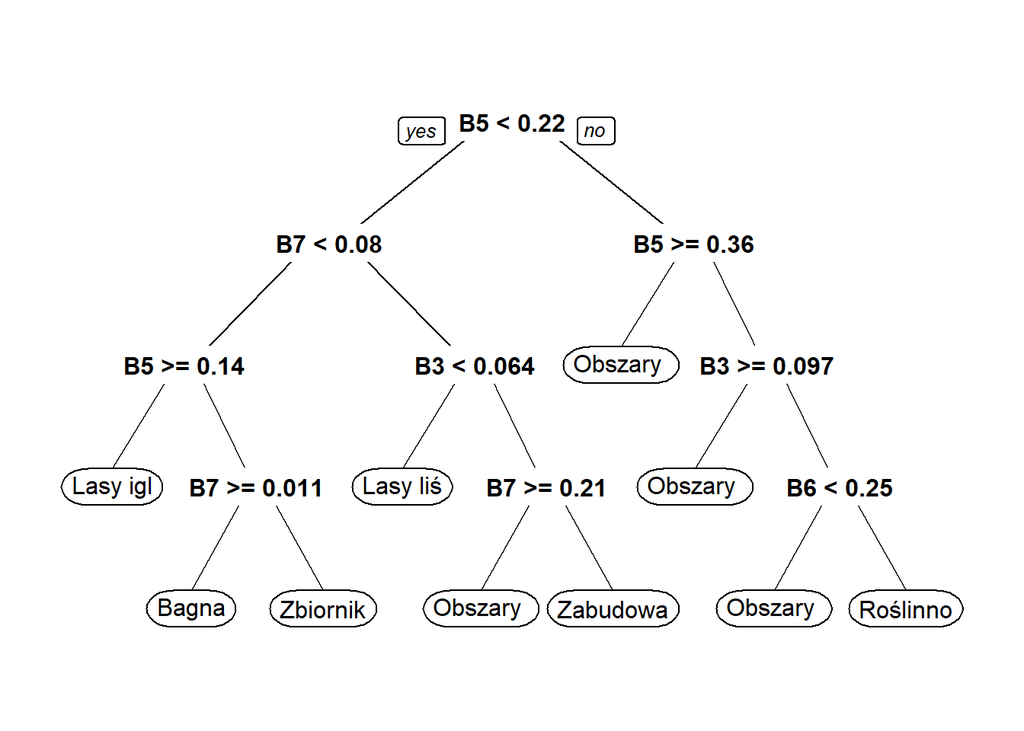

```r
prp(mdl)
```

# Walidacja

Sprawdźmy teraz jaka jest skuteczność stworzonego modelu klasyfikacyjnego na zbiorze testowym. W tym celu należy wykorzystać funkcję `predict()`. Zbiór danych testowych musi posiadać dokładnie te same zmienne wyjaśniające co zbiór treningowy. Kolumnę z prawdziwymi (rzeczywistymi) klasami należy pominąć (usunąć).

```r
pred = predict(mdl, test[, -8], type = "class")
unname(head(pred)) # `unname()` usuwa numer porządkowy wiersza/piksela
```

```
[1] Obszary uprawne Obszary uprawne Obszary uprawne Obszary uprawne
[5] Zabudowa        Obszary uprawne
8 Levels: Bagna Lasy iglaste Lasy liściaste ... Zbiorniki wodne
```

Wykonaliśmy predykcje dla zbioru testowego. Teraz musimy obliczyć miarę (wskaźnik) skuteczności. Jako przykład wybierzemy dokładność (*accuracy*) definiowaną jako iloraz poprawnych klasyfikacji do wszystkich (poprawnych i niepoprawnych) klasyfikacji.

```r
pop_klas = test$klasa == pred # zwraca wartość logiczną czy klasa jest prawidłowa
sum(pop_klas) / length(pop_klas)
```

```
[1] 0.7138344
```

Skuteczność naszego modelu wynosi około 71%. Oprócz jednej ogólnej statystyki możemy sprawdzić również błędy klasyfikacji dla poszczególnych klas. Takie zestawienie nazywane jest tabelą pomyłek (*confusion matrix*).

```r
table(pred = pred, true = test$klasa)
```

```
                      true
pred                   Bagna Lasy iglaste Lasy liściaste Obszary uprawne
  Bagna                 1339          150             85              26
  Lasy iglaste           251        17542           2298             106
  Lasy liściaste        2133         3159          12183             709
  Obszary uprawne       2034         1375           3563           93946
  Roślinność trawiasta   934          229            405            2855
  Torfowiska               0            0              0               0
  Zabudowa               900          431            701            1017
  Zbiorniki wodne        133            5              0               3
                      true
pred                   Roślinność trawiasta Torfowiska Zabudowa Zbiorniki wodne
  Bagna                                  59         23       74             383
  Lasy iglaste                           69        195       99              12
  Lasy liściaste                       1058        526      441              10
  Obszary uprawne                     20077        482     6554               3
  Roślinność trawiasta                 7190         49      211               0
  Torfowiska                              0          0        0               0
  Zabudowa                              933         94     3286               8
  Zbiorniki wodne                        11          0       15            1431
```

Poprawnie sklasyfikowane obiekty znajdują się na przekątnej. Obiekty sklasyfikowane jako fałszywe pozytywne (*false positive*) znajdują się w prawej górnej części, natomiast obiekty sklasyfikowane jako fałszywe negatywne (*false negative*) w lewej dolnej części.

# Finalna mapa

Jeśli opracowany model spełnia nasze oczekiwania, to możemy wykorzystać go do predykcji na całym obszarze. Ponownie użyjemy funkcję `predict()`, ale tym razem jako dane wejściowe posłuży raster `landsat`. Dodatkowo, powinniśmy ustawić argument `na.rm = TRUE`, aby uniknąć predykcji poza obszarem analizy.

```r
pred_map = predict(landsat, mdl, type = "class", na.rm = TRUE)
```

Jako wynik powyższej operacji otrzymaliśmy mapę (SpatRaster) z predykcją klas pokrycia terenu. Przygotujmy wizualizację wykorzystując dostarczoną legendę (obiekt `legenda`). W pierwszej kolumnie znajdziemy ID klasy, w drugiej wartość koloru RGB w zapisie szesnastkowym, a w trzeciej nazwę klasy.

Przygotowanie legendy składa się z dwóch etapów:

1. Sprawdzenie, które klasy rzeczywiście występują na naszym obszarze
2. Dopasowanie kolorów do odpowiednich klas

Odnośnie pierwszego punktu, to najprościej wykorzystać funkcję `droplevels()`, która usunie puste kategorie z rastra (np. winnica, wrzosowisko). Następnie należy wyświetlić kategorie za pomocą funkcji `levels()`. Do każdej warstwy rastra mogą być przypisane różne kategorie, więc musimy pobrać je tylko dla pierwszej warstwy oraz wskazać atrybut `class`.

Dopasowania kolorów można dokonać za pomocą funkcji `match()`. Jako pierwszy wskazujemy obiekt z naszymi klasami, jako drugi obiekt ramkę danych ze schematem kolorów (`legenda`) i w wyniku otrzymamy dopasowane indeksy kolorów.

```r
lv = droplevels(pred_map) # usuń puste kategorie z rastra
lv = levels(lv) # zwróć kategorie jako ramkę danych
lv = lv[[1]][["class"]] # wybierz pierwszą warstwę i kolumnę z nazwami klas
```

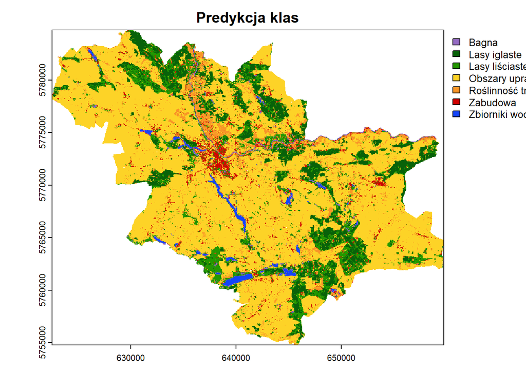

```r
col_idx = match(lv, legenda$Klasa) # dopasuj klasy do odpowiednich kolorów
plot(pred_map, main = "Predykcja klas", col = legenda$RGB[col_idx])
```

W przypadku, gdy raster posiada oryginalne ID klas (tj. 0, 62, 73, 75, itd.), to można przypisać ramkę danych do rastra.

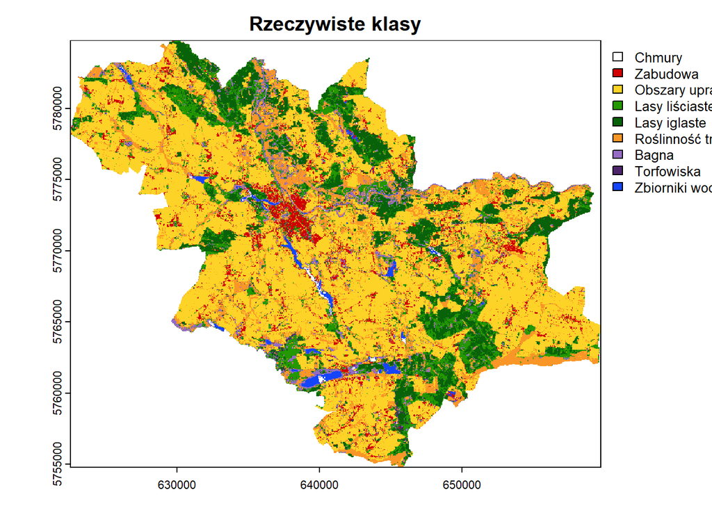

```r
levels(s2glc) = legenda[, c(1, 3)]
lv = levels(droplevels(s2glc))[[1]][["Klasa"]]
col_idx = match(lv, legenda$Klasa)
plot(s2glc, col = legenda$RGB[col_idx], main = "Rzeczywiste klasy")
```

# Zadanie

**8.** Pobierz scenę satelitarną o niskim zachmurzeniu i dotnij jej zasięg do wybranego powiatu. Następnie dokonaj klasyfikacji nadzorowanej używając dowolnie wybranych danych referencyjnych o pokryciu terenu, np. [S2GLC](https://s2glc.cbk.waw.pl/), [CLC](https://land.copernicus.eu/en/products/corine-land-cover) czy [BDOT10K:Pokrycie Terenu](https://www.geoportal.gov.pl/pl/dane/baza-danych-obiektow-topograficznych-bdot10k/) (liczba klas nie powinna być zbyt duża). Po wytrenowaniu modelu klasyfikacyjnego oceń jego skuteczność na zbiorze testowym oraz oblicz procentowy udział poszczególnych klas pokrycia terenu na analizowanym obszarze. Finalnie, porównaj wyniki klasyfikacji z mapą referencyjną używając identycznego schematu kolorów.